kaggle中对泰坦尼克号数据的描述是这样的

在1912年4月15日，泰坦尼克号与冰山相撞后沉船，船上共有2224人，其中1502人死亡，存活率为32%

导致这场海难的一个主要原因就是救生艇不够。虽然幸存下来是有一定运气成分在里面的，但是还是会有一些人比其他人更容易存活下来，就比如妇女、儿童和上流社会

数据挖掘的目标是，找出哪种人更容易存活，并对其他人能否幸存进行预测

导入数据挖掘所需的库

```python
%matplotlib inline

import pandas as pd
import numpy as np

from matplotlib import pyplot as plt
import seaborn as sns

from sklearn.tree import DecisionTreeClassifier,DecisionTreeRegressor
from sklearn.model_selection import cross_val_score,GridSearchCV

import warnings
warnings.filterwarnings("ignore")
```

读取数据

```python
train = pd.read_csv("titanic/train.csv")
test = pd.read_csv("titanic/test.csv")
results = pd.read_csv("titanic/gender_submission.csv")
data = results.Survived
test.insert(0,'Survived',data)
```

下面开始进行数据质量分析

```python
#展示数据的相关信息
train.info()
```

```
<class 'pandas.core.frame.DataFrame'>
RangeIndex: 891 entries, 0 to 890
Data columns (total 12 columns):
PassengerId    891 non-null int64
Survived       891 non-null int64
Pclass         891 non-null int64
Name           891 non-null object
Sex            891 non-null object
Age            714 non-null float64
SibSp          891 non-null int64
Parch          891 non-null int64
Ticket         891 non-null object
Fare           891 non-null float64
Cabin          204 non-null object
Embarked       889 non-null object
dtypes: float64(2), int64(5), object(5)
memory usage: 83.6+ KB
```

统计属性中的缺失值

```python
total = train.isnull().sum().sort_values(ascending=False)
percent = round(train.isnull().sum().sort_values(ascending=False)/len(train)*100,2)
pd.concat([total,percent],axis=1,keys=['total','percent'])
```

|  | total | percent |
| --- | --- | --- |
| Cabin | 687 | 77.10 |
| Age | 177 | 19.87 |
| Embarked | 2 | 0.22 |
| Fare | 0 | 0.00 |
| Ticket | 0 | 0.00 |
| Parch | 0 | 0.00 |
| SibSp | 0 | 0.00 |
| Sex | 0 | 0.00 |
| Name | 0 | 0.00 |
| Pclass | 0 | 0.00 |
| Survived | 0 | 0.00 |
| PassengerId | 0 | 0.00 |

通过上面的分析可以发现，训练数据共有891条，其中有连续类型的特征，也有离散类型的特征，还发现了Cabin、Age和Embarked是含有缺失数据的，缺失的占比分别是77.1%、19.87%和0.22%

这里的缺失数据不算少，而缺失的原因可能就是年代过于久远，有些数据并没有保存下来，或者在当时就没有记录清楚

```python
train.describe()
```

|  | PassengerId | Survived | Pclass | Age | SibSp | Parch | Fare |
| --- | --- | --- | --- | --- | --- | --- | --- |
| count | 891.000000 | 891.000000 | 891.000000 | 714.000000 | 891.000000 | 891.000000 | 891.000000 |
| mean | 446.000000 | 0.383838 | 2.308642 | 29.699118 | 0.523008 | 0.381594 | 32.204208 |
| std | 257.353842 | 0.486592 | 0.836071 | 14.526497 | 1.102743 | 0.806057 | 49.693429 |
| min | 1.000000 | 0.000000 | 1.000000 | 0.420000 | 0.000000 | 0.000000 | 0.000000 |
| 25% | 223.500000 | 0.000000 | 2.000000 | 20.125000 | 0.000000 | 0.000000 | 7.910400 |
| 50% | 446.000000 | 0.000000 | 3.000000 | 28.000000 | 0.000000 | 0.000000 | 14.454200 |
| 75% | 668.500000 | 1.000000 | 3.000000 | 38.000000 | 1.000000 | 0.000000 | 31.000000 |
| max | 891.000000 | 1.000000 | 3.000000 | 80.000000 | 8.000000 | 6.000000 | 512.329200 |

通过describe函数统计的结果可以发现，PassengerId是乘客ID，没有什么实质的作用；然后是Survived，这是对是否能够幸存的标记，1代表幸存，0代表死亡；Pclass是船舱等级，级别从大到小为1>2>3；然后是属性Age，从平均值和四分位数都可以看出，该份数据中的乘客整体呈成年的分布，小孩和老人只占少部分，最小值是0.42，这代表有不满一岁的婴儿，最大年龄为80岁；关于SibSp，该属性是堂兄弟/妹个数，最小是0，最大是8，但是仅从这个是看不出具体家庭的分布情况，需要进一步进行分析；然后是Parch，该属性是父母与小孩个数，最小值是0，代表没有，最大值为6，但是也不能看出太多东西，需要进一步进行可视化分析；最后是Fare，该值代表票价，中位数是14，但是最大值为512，证明该属性出现了严重的右偏现象，感觉512对应的数据可能是异常值，需要进一步分析

下面通过箱型图对各属性的异常值进行具体分析

属性Age

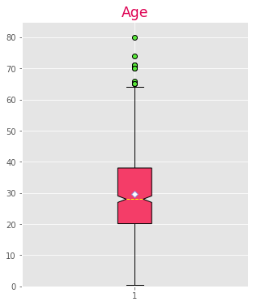

```python
temporary_train = train.dropna(subset=["Age"])  #删除含有缺失年龄的观测
plt.style.use("ggplot")  #使用ggplot的图形style
plt.figure(figsize=(5,6))
boxplot = plt.boxplot(
    x = temporary_train.Age,     # 绘图数据
    notch = True,      #设置中位线处凹陷，（注意：下图看起来有点丑）
    patch_artist=True, # 设置用自定义颜色填充盒形图，默认白色填充
    showmeans=True,    # 以点的形式显示均值
    boxprops = {"color":"black","facecolor":"#F43D68"}, # 设置箱体属性，填充色and 边框色
    flierprops = {"marker":"o","markerfacecolor":"#59EA3A","color":"#59EA3A"}, # 设置异常值属性，点的形状、填充色和边框色
    meanprops = {"marker":"D","markerfacecolor":"white"}, # 设置均值点的属性，点的形状、填充色
    medianprops = {"linestyle":"--","color":"#FBFE00"}         # 设置中位数线的属性，线的类型和颜色
    )
plt.ylim(0,85)  # 设置y轴的取值范围
plt.title("Age",fontsize="xx-large",color="#DE0052")
plt.show()
```

平均年龄为30，年龄整体分布在20到38之间，中位线偏下，异常值多在上限值之外，说明年龄整体右偏；有偏大的异常值在64岁以上。

可视化Fare属性

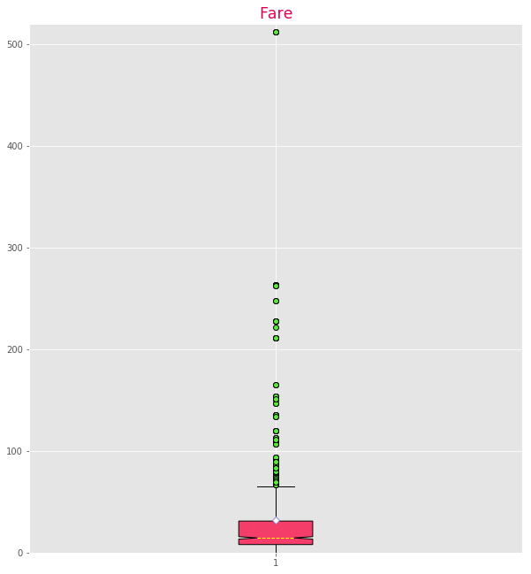

```python
plt.style.use("ggplot")  #使用ggplot的图形style
plt.figure(figsize=(10,11))
boxplot = plt.boxplot(
    x = train.Fare,    # 绘图数据
    notch = True,      #设置中位线处凹陷，（注意：下图看起来有点丑）
    patch_artist=True, # 设置用自定义颜色填充盒形图，默认白色填充
    showmeans=True,    # 以点的形式显示均值
    boxprops = {"color":"black","facecolor":"#F43D68"}, # 设置箱体属性，填充色and 边框色
    flierprops = {"marker":"o","markerfacecolor":"#59EA3A","color":"#59EA3A"}, # 设置异常值属性，点的形状、填充色和边框色
    meanprops = {"marker":"D","markerfacecolor":"white"}, # 设置均值点的属性，点的形状、填充色
    medianprops = {"linestyle":"--","color":"#FBFE00"}         # 设置中位数线的属性，线的类型和颜色
    )
plt.ylim(0,520)  # 设置y轴的取值范围
plt.title("Fare",fontsize="xx-large",color="#DE0052")
plt.show()
```

箱体扁平，异常值非常明显，需要进行处理，这里可以对Fare使用对数处理

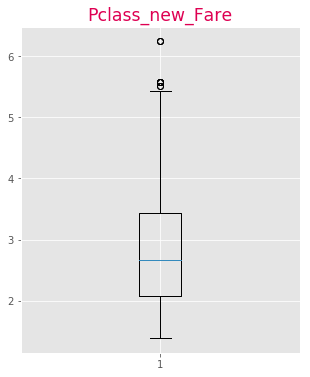

```python
x = train.Fare
train["new_Fare"] = np.log(x)
plt.figure(figsize=(5,6))
plt.boxplot(x="new_Fare",data=train)
plt.title("Pclass_new_Fare",fontsize="xx-large",color="#DE0052")
plt.show()
```

现在中位线和数据的分布情况都可以很明显的看出来，并且异常值也没那么明显了

下面在Pclass变量的基础之上，对Fare进行观察

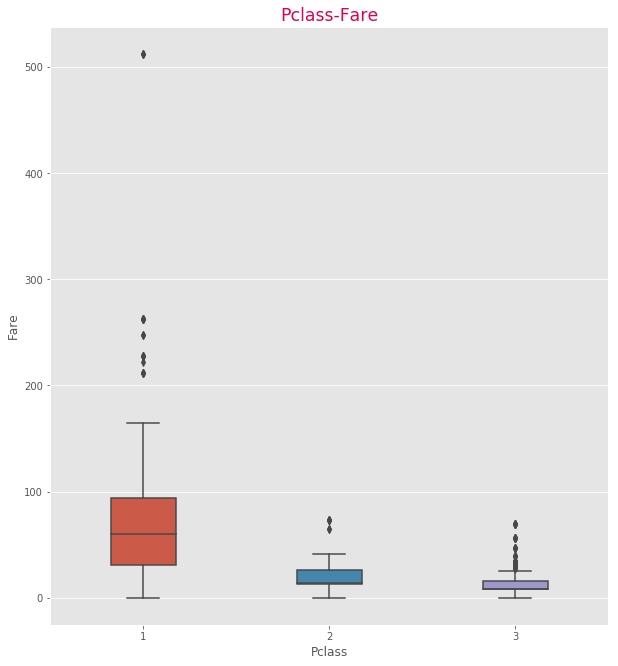

```python
plt.figure(figsize=(10,11))
sns.boxplot(x="Pclass",y="Fare",data=train,width=0.35)
plt.title("Pclass-Fare",fontsize="xx-large",color="#DE0052")
plt.show()
```

通过上图可以发现，票价呈现右偏现象，票价中位数：级别1 > 级别2 > 级别3。级别1、2、3中都有偏高的票价

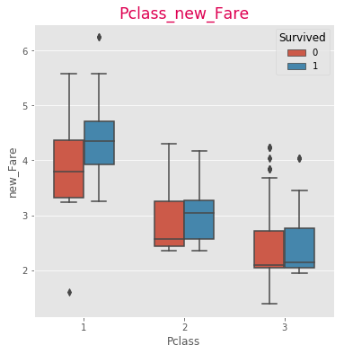

```python
plt.figure(figsize=(6,6))
sns.boxplot(x="Pclass",y="new_Fare",hue="Survived",data=train,width=0.6)
plt.title("Pclass_new_Fare",fontsize="xx-large",color="#DE0052")
plt.show()
```

随着船舱等级的升高，船票价格也是随之升高的。 而且在同一船舱等级中，存活下来的乘客的票价中位数均比死亡乘客的票价中位数要高。 在级别1中，死亡乘客中存在一个票价异常低的乘客，而存活下来的乘客中存在一个票价异常高的乘客。 在级别3中，死亡乘客中存在票价异常高的乘客，生存乘客中也存在一个票价异常高的乘客

上面是数据的质量进行分析，来找出数据中的脏数据，也就是那些不能直接拿来进行挖掘的数据

下面开始进行数据特征分析

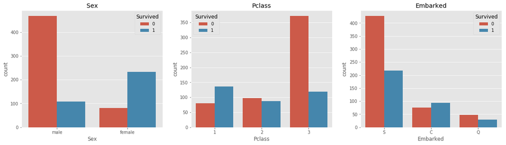

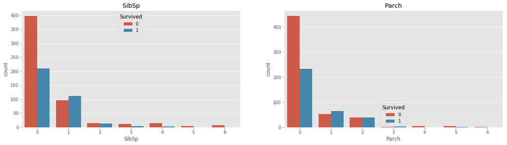

```python
f, [ax1,ax2,ax3] = plt.subplots(1,3,figsize=(20,5))
sns.countplot(x='Sex', hue='Survived', data=train, ax=ax1)
sns.countplot(x='Pclass', hue='Survived', data=train, ax=ax2)
sns.countplot(x='Embarked', hue='Survived', data=train, ax=ax3)
ax1.set_title('Sex')
ax2.set_title('Pclass')
ax3.set_title('Embarked')

f, [ax1,ax2] = plt.subplots(1,2,figsize=(20,5))
sns.countplot(x='SibSp', hue='Survived', data=train, ax=ax1)
sns.countplot(x='Parch', hue='Survived', data=train, ax=ax2)
ax1.set_title('SibSp')
ax2.set_title('Parch')

plt.show()
```

```python
train[['Sex','Survived']].groupby(['Sex'],as_index=False).mean().sort_values(by='Survived',ascending=False)
```

|  | Sex | Survived |
| --- | --- | --- |
| 0 | female | 0.742038 |
| 1 | male | 0.188908 |

综合统计结果可知，在Sex中，女性能够幸存下来的要更多，幸存概率达到了74%，而男性幸存的概率很少，幸存率仅为19%，这也表明女性可以获得优先上救生艇的原则，同时证明该属性与是否幸存之间的关系是很大的；

```python
train[['Pclass','Survived']].groupby(['Pclass'],as_index=False).mean().sort_values(by='Survived',ascending=False)
```

|  | Pclass | Survived |
| --- | --- | --- |
| 0 | 1 | 0.629630 |
| 1 | 2 | 0.472826 |
| 2 | 3 | 0.242363 |

在Pclass中，级别1中的获救者占比更多，幸存概率达到了63%，级别2中表现不明显，死亡与幸存之间人数的占比基本持平，幸存概率达到了47%，而级别3中，死亡人数占的更多，并且还能看出该级别的人数也比其他级别多很多，幸存概率为24%，所以从这个现象中可以知道，级别越高的人幸存的可能就越大，这是因为级别越高则代表社会地位可能就越高，这是比较符合实际规律的

```python
train[['Embarked','Survived']].groupby(['Embarked'],as_index=False).mean().sort_values(by='Survived',ascending=False)
```

|  | Embarked | Survived |
| --- | --- | --- |
| 0 | C | 0.553571 |
| 1 | Q | 0.389610 |
| 2 | S | 0.336957 |

```python
train[['SibSp','Survived']].groupby(['SibSp'],as_index=False).mean().sort_values(by='Survived',ascending=False)
```

|  | SibSp | Survived |
| --- | --- | --- |
| 1 | 1 | 0.535885 |
| 2 | 2 | 0.464286 |
| 0 | 0 | 0.345395 |
| 3 | 3 | 0.250000 |
| 4 | 4 | 0.166667 |
| 5 | 5 | 0.000000 |
| 6 | 8 | 0.000000 |

从SibSp属性中可以发现，SibSp的整体规律是随着其逐渐升高，幸存的概率是在逐渐下降的，也就是SibSp与Survived之间是有一定关联的，需要进一步分析

```python
train[['Parch','Survived']].groupby(['Parch'],as_index=False).mean().sort_values(by='Survived',ascending=False)
```

|  | Parch | Survived |
| --- | --- | --- |
| 3 | 3 | 0.600000 |
| 1 | 1 | 0.550847 |
| 2 | 2 | 0.500000 |
| 0 | 0 | 0.343658 |
| 5 | 5 | 0.200000 |
| 4 | 4 | 0.000000 |
| 6 | 6 | 0.000000 |

从整体来看，与SibSp的规律是一样的

下面综合考虑SibSp与Parch这两个属性，将SibSp加Parch可以得到属性家庭规模，来分析家庭规模与幸存与否之间的关系

```python
train['FS'] = train['SibSp'] + train['Parch'] + 1
```

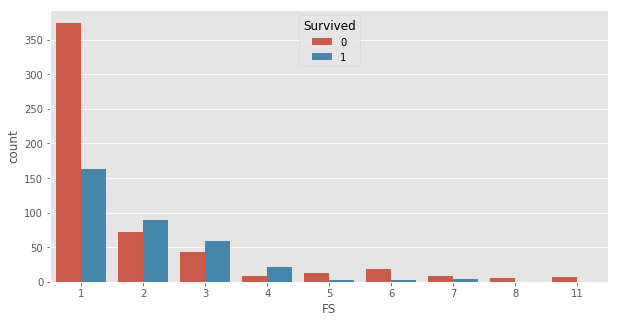

```python
fig, ax = plt.subplots(figsize=(10,5))
sns.countplot(x='FS', hue='Survived',data=train)
plt.show()
```

```python
train[['FS','Survived']].groupby(['FS'],as_index=False).mean().sort_values(by='Survived',ascending=False)
```

|  | FS | Survived |
| --- | --- | --- |
| 3 | 4 | 0.724138 |
| 2 | 3 | 0.578431 |
| 1 | 2 | 0.552795 |
| 6 | 7 | 0.333333 |
| 0 | 1 | 0.303538 |
| 4 | 5 | 0.200000 |
| 5 | 6 | 0.136364 |
| 7 | 8 | 0.000000 |
| 8 | 11 | 0.000000 |

在这里我基于SibSp和Parch的和算出了家庭成员的总数，想看看家庭成员规模与幸存与否之间的关系

从结果看出，家庭成员总数为4时，幸存概率竟然达到了72%，剩下表现较好的也只有3和2了，至于其他的家庭规模的幸存概率则普遍偏小

这里有个很明显的结果，就是当家庭成员总数为4时的幸存概率要明显高于其他规模的家庭，所以我打算调取出所有FS为4的数据做一下观察

```python
train_fs_four = train.loc[(train.FS == 4)]
```

```python
train_fs_four.describe(include=['O'])
```

|  | Name | Sex | Ticket | Cabin | Embarked |
| --- | --- | --- | --- | --- | --- |
| count | 29 | 29 | 29 | 9 | 29 |
| unique | 29 | 2 | 13 | 3 | 2 |
| top | Becker, Master. Richard F | female | 113760 | B96 B98 | S |
| freq | 1 | 19 | 4 | 4 | 22 |

家庭成员为4的数据一共有29条，其中多数为女性，有19个；大多数是从S港口登船的，有22个

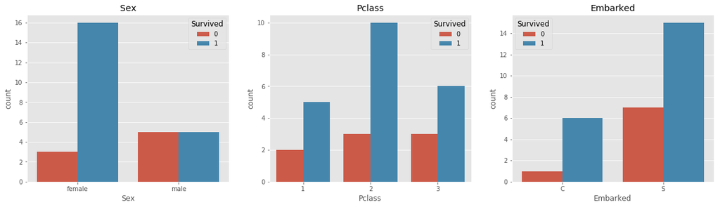

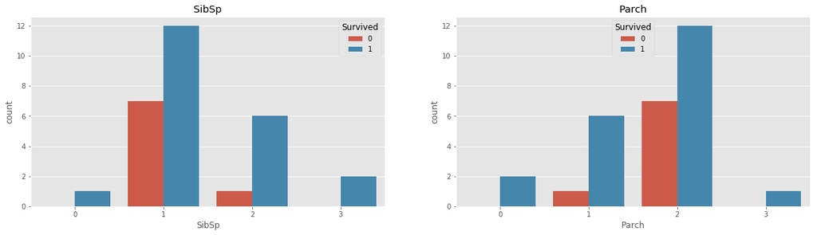

```python
f, [ax1,ax2,ax3] = plt.subplots(1,3,figsize=(20,5))
sns.countplot(x='Sex', hue='Survived', data=train_fs_four, ax=ax1)
sns.countplot(x='Pclass', hue='Survived', data=train_fs_four, ax=ax2)
sns.countplot(x='Embarked', hue='Survived', data=train_fs_four, ax=ax3)
ax1.set_title('Sex')
ax2.set_title('Pclass')
ax3.set_title('Embarked')

f, [ax1,ax2] = plt.subplots(1,2,figsize=(20,5))
sns.countplot(x='SibSp', hue='Survived', data=train_fs_four, ax=ax1)
sns.countplot(x='Parch', hue='Survived', data=train_fs_four, ax=ax2)
ax1.set_title('SibSp')
ax2.set_title('Parch')

plt.show()
```

```python
train_fs_four[['Sex','Survived']].groupby(['Sex'],as_index=False).mean().sort_values(by='Survived',ascending=False)
```

|  | Sex | Survived |
| --- | --- | --- |
| 0 | female | 0.842105 |
| 1 | male | 0.500000 |

```python
train_fs_four[['Pclass','Survived']].groupby(['Pclass'],as_index=False).mean().sort_values(by='Survived',ascending=False)
```

|  | Pclass | Survived |
| --- | --- | --- |
| 1 | 2 | 0.769231 |
| 0 | 1 | 0.714286 |
| 2 | 3 | 0.666667 |

```python
train_fs_four[['Embarked','Survived']].groupby(['Embarked'],as_index=False).mean().sort_values(by='Survived',ascending=False)
```

|  | Embarked | Survived |
| --- | --- | --- |
| 0 | C | 0.857143 |
| 1 | S | 0.681818 |

```python
train_fs_four[['SibSp','Survived']].groupby(['SibSp'],as_index=False).mean().sort_values(by='Survived',ascending=False)
```

|  | SibSp | Survived |
| --- | --- | --- |
| 0 | 0 | 1.000000 |
| 3 | 3 | 1.000000 |
| 2 | 2 | 0.857143 |
| 1 | 1 | 0.631579 |

```python
train_fs_four[['Parch','Survived']].groupby(['Parch'],as_index=False).mean().sort_values(by='Survived',ascending=False)
```

|  | Parch | Survived |
| --- | --- | --- |
| 0 | 0 | 1.000000 |
| 3 | 3 | 1.000000 |
| 1 | 1 | 0.857143 |
| 2 | 2 | 0.631579 |

上面可以发现在SibSp为0或3的时候，或者当Parch为0或3的时候幸存概率为100%，所以需要调取出相应数据查看原因

```python
train_fs_four[(train_fs_four['SibSp'] == 0) | (train_fs_four['SibSp'] == 3) & ((train_fs_four['Parch'] == 0) | (train_fs_four['Parch'] == 3))]
```

|  | PassengerId | Survived | Pclass | Name | Sex | Age | SibSp | Parch | Ticket | Fare | Cabin | Embarked | new_Fare | FS |
| --- | --- | --- | --- | --- | --- | --- | --- | --- | --- | --- | --- | --- | --- | --- |
| 85 | 86 | 1 | 3 | Backstrom, Mrs. Karl Alfred (Maria Mathilda Gu... | female | 33.0 | 3 | 0 | 3101278 | 15.8500 | NaN | S | 2.763170 | 4 |
| 726 | 727 | 1 | 2 | Renouf, Mrs. Peter Henry (Lillian Jefferys) | female | 30.0 | 3 | 0 | 31027 | 21.0000 | NaN | S | 3.044522 | 4 |
| 858 | 859 | 1 | 3 | Baclini, Mrs. Solomon (Latifa Qurban) | female | 24.0 | 0 | 3 | 2666 | 19.2583 | NaN | C | 2.957942 | 4 |

结果显示，之所以会这样是因为都是女性的缘故

综合上面所有的可视化结果，我觉得在这份29条数据中，之所以这29个人幸存的概率很高，有很大原因是因为这些人中大多数都是女性，这是最明显的规律，也进一步证明性别在是否能够幸存中的作用是很关键的

对数据进行基本的分析后，下面可以进入数据挖掘中的预处理阶段

处理缺失数据

```python
total = train.isnull().sum().sort_values(ascending=False)
percent = round(train.isnull().sum().sort_values(ascending=False)/len(train)*100,2)
pd.concat([total,percent],axis=1,keys=['total','percent'])
```

[output not shown]

检查完训练数据中的缺失项之后就可以开始处理缺失值了，因为在模型训练时数据中是不能包含缺失值的，所以要在之前处理它们，以获得可信的数据。而关于处理的方式是可以这么判断的，首先确定产生数据缺失的原因，而原因一般是，无法获取或获取代价太大，或是人为因素或设备故障造成的，再者就是缺失是合理存在的，判断好以后还要再确定缺失值的缺失是否与其他变量的关系，最后针对不同的情况使用不同的处理方式

如果是没有关系，则可以采用直接删除的方式，不过删除也要有个前提：样本数量要足够多且缺失数据较少时才比较合适。但如果不能采用直接删除的方式，则可以采用比如，用众数填充、中位数填充、平均值填充、用相似数据中的值填充、用聚类算法所得的结果填充、用其他机器学习算法以缺失项为目标变量进行预测的值来填充，当然也可以不进行处理，因为不管如何处理都会导致原始数据分布的变化，也有可能引入新的噪声，所以不进行处理也是一种方式，但是必须要选择一个对缺失值不敏感的、可以处理缺失值的模型

根据之前对缺失值的统计结果，因为Embarket缺失值很少，所以可以从Embarket开始处理

```python
percent = pd.DataFrame(round(train.Embarked.value_counts(dropna=False,normalize=True)*100,2))
total = pd.DataFrame(train.Embarked.value_counts(dropna=False))
pd.concat([total,percent],axis=1,keys=['total','percent'])
```

|  | total Embarked | percent Embarked |
| --- | --- | --- |
| S | 644 | 72.28 |
| C | 168 | 18.86 |
| Q | 77 | 8.64 |
| NaN | 2 | 0.22 |

从对Embarked属性中不同取值的统计结果可以看出来，有72%的人是从S登船的，有19%的人是从C登船的，有9%的人是从Q登船的，还含有两个缺失数据，既然只有两条，那么其实是可以直接调取出来看一下的

```python
train[train.Embarked.isnull()]
```

|  | PassengerId | Survived | Pclass | Name | Sex | Age | SibSp | Parch | Ticket | Fare | Cabin | Embarked | new_Fare | FS |
| --- | --- | --- | --- | --- | --- | --- | --- | --- | --- | --- | --- | --- | --- | --- |
| 61 | 62 | 1 | 1 | Icard, Miss. Amelie | female | 38.0 | 0 | 0 | 113572 | 80.0 | B28 | NaN | 4.382027 | 1 |
| 829 | 830 | 1 | 1 | Stone, Mrs. George Nelson (Martha Evelyn) | female | 62.0 | 0 | 0 | 113572 | 80.0 | B28 | NaN | 4.382027 | 1 |

因为缺失数据很少，只有两条，所以是可以考虑直接将其删除的，但是为了保持数据的完整性，所以也可以考虑使用某个值来填充，这里我打算使用相似数据的值进行填充。根据数据，这两个人都幸存了下来，且船舱等级都是最高级1，并且都是女性。所以可以根据这三个属性来找相似的数据，下面通过可视化的方式寻找规律

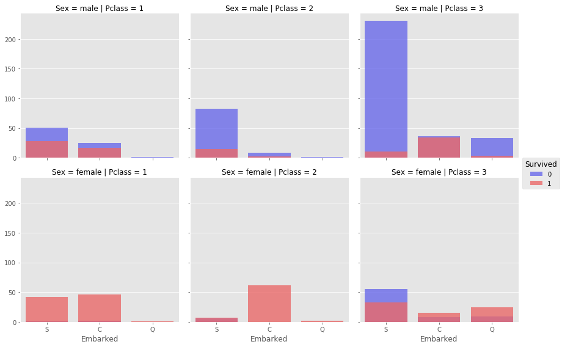

```python
grid = sns.FacetGrid(train, row='Sex', col='Pclass', hue='Survived', palette='seismic', size=4)
grid.map(sns.countplot, 'Embarked', alpha=0.8)
grid.add_legend()
```

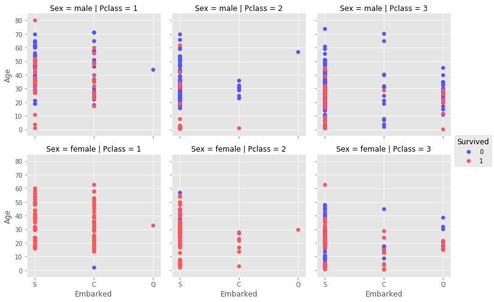

```python
#Sex，Embarked分类条件下的 Age年龄对Survived的散点图
grid = sns.FacetGrid(train, col = "Pclass", row = "Sex", hue = "Survived", palette = 'seismic', size=3.5)
grid = grid.map(plt.scatter,"Embarked","Age")
grid.add_legend()
grid
```

我这里是调查了与缺失数据相似的数据来看看有什么规律，通过柱状图和散点图都可以发现，Sex为女，Pclass为1的时候，基本都是幸存的，所以可以采用相似数据中的值进行填充

这里是根据与缺失数据相似的数据进行填充的，所以根据可视化的结果可以发现，性别为女，等级为1的幸存者基本都来自S和C，但是从C登船的人更多一些，所以根据众数的原则可以用C来填充

```python
train.Embarked.fillna('C',inplace=True)
```

Embarked的缺失值处理完以后，就可以处理Age了，因为属性Age的缺失值占总数的20%，缺失过多，所以不适宜直接删除，因为如果删除会导致丢失重要数据信息的问题，所以应该探索其他的解决方案，下面进行一些可视化分析，来寻找合适的处理方式

```python
train.describe()['Age']
```

```
count    714.000000
mean      29.699118
std       14.526497
min        0.420000
25%       20.125000
50%       28.000000
75%       38.000000
max       80.000000
Name: Age, dtype: float64
```

在Age中，最小值为0.42，估计是刚出生没多久的宝宝，而最大值是80，他们之间差距较大，需要进一步分析

```
Text(0,0.5,'Frequency')
```

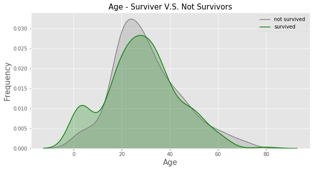

```python
f,ax = plt.subplots(figsize=(10,5))
sns.kdeplot(train.loc[(train['Survived'] == 0),'Age'] , color='gray',shade=True,label='not survived')
sns.kdeplot(train.loc[(train['Survived'] == 1),'Age'] , color='g',shade=True, label='survived')
plt.title('Age - Surviver V.S. Not Survivors', fontsize = 15)
plt.xlabel("Age", fontsize = 15)
plt.ylabel('Frequency', fontsize = 15)
```

这是生与死之间Age的折线图，可以发现大多数人的年龄在20-40岁之间，但是基于此也不能证明什么太多的东西，所以还需要继续分析

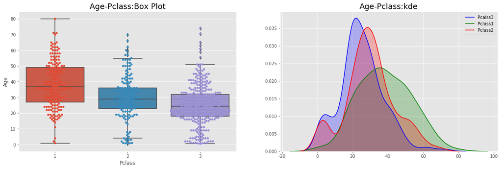

```python
# 箱型图特征分析
fig, [ax1,ax2] = plt.subplots(1,2,figsize=(20,6))
sns.boxplot(x="Pclass", y="Age", data=train, ax =ax1)
sns.swarmplot(x="Pclass", y="Age", data=train, ax =ax1)
sns.kdeplot(train.loc[(train['Pclass'] == 3),'Age'] , color='b',shade=True, label='Pcalss3',ax=ax2)
sns.kdeplot(train.loc[(train['Pclass'] == 1),'Age'] , color='g',shade=True, label='Pclass1',ax=ax2)
sns.kdeplot(train.loc[(train['Pclass'] == 2),'Age'] , color='r',shade=True, label='Pclass2',ax=ax2)
ax1.set_title('Age-Pclass:Box Plot', fontsize = 18)
ax2.set_title("Age-Pclass:kde", fontsize = 18)
fig.show()
```

从这张图可以发现，Age与不同Pclass之间存在着不同的分布情况，Pclass表示的是船舱等级，从高到低对应着Pclass1>Pclass2>Pclass3，图中显示随着等级的提高年龄的整体分布情况成升高趋势，而这也正好符合真实情况，年龄越高船舱等级越高，这是因为随着年龄的增长，财富和社会地位都更有可能提高，所以船舱等级也会提高

所以，根据上面可视化的结果，我觉得可以根据Pclass的不同分布来进行填充，具体来说就是使用不同分布中关于Age的平均值来进行填充

针对Age属性填充的方式一

```python
import scipy
#注意：shapiro 不适合做样本数＞5000的正态性检验，检验结果的P值可能不准确
#一般p>0.05就是正态
scipy.stats.shapiro(train.Age)
```

```
(nan, 1.0)
```

```python
#针对属性Pclass的不同分布来确定Age的平均值
Age1 = int(train.loc[train.Pclass == 1,'Age'].mean())
Age2 = int(train.loc[train.Pclass == 2,'Age'].mean())
Age3 = int(train.loc[train.Pclass == 3,'Age'].mean())
```

```python
#根据Pclass拆分数据
train1 = train.loc[train.Pclass == 1]
train2 = train.loc[train.Pclass == 2]
train3 = train.loc[train.Pclass == 3]
```

```python
#填充
train1.Age.fillna(Age1,inplace=True)
train2.Age.fillna(Age2,inplace=True)
train3.Age.fillna(Age3,inplace=True)
```

```python
#将拆分出来的数据合并起来
train = pd.concat([train1,train2,train3])
```

```python
#将数据打乱
train.sort_values("PassengerId",inplace=True)
```

上面是根据不同的分布对Age中的缺失值进行填充

其实还有一种方式可以填充Age中的缺失值，那就是使用机器学习算法以Age为目标变量进行预测，然后以预测的值进行填充，但是还需要处理几个属性，就像上面所看到的，有些属性还不是数值类型的，所以如果不是数值类型的属性是不能输入到机器学习算法中进行学习的

针对Age属性填充的方式二

在将数据输入到模型中进行学习之前，必须对非数值类型的属性进行处理，并且在这个过程中还可以使用数据本身的属性衍生出新的属性，因为对于数据分析来说，只使用数据本身的信息有时候是不够的，还必须根据已有的数据衍生出新的属性进行分析，并且有时候这些衍生出来的信息反而更为有用

```python
train.info()
```

[output not shown]

```python
import re
train["Title"] = train["Name"].apply(lambda x: re.search(' ([A-Za-z]+)\.',x).group(1))
title_mapping = {"Mr": 1, "Miss": 2, "Mrs": 3, "Master": 4, "Dr": 5, "Rev": 6, "Major": 7, "Col": 7, "Mlle": 2, "Mme": 3,"Don": 9,"Dona": 9, "Lady": 10, "Countess": 10, "Jonkheer": 10, "Sir": 9, "Capt": 7, "Ms": 2}

# 量化Title信息
train["NewTitle"] = train.loc[:,'Title'].map(title_mapping)

# SibSp和Parch特征进行组合
train["FamilySize"] = train["SibSp"] + train["Parch"] + 1

# 根据FamilySize分布进行分箱
train["FamilySize"] = pd.cut(train["FamilySize"], bins=[0,1,4,20], labels=[0,1,2])

# 从Name衍生出Name的长度
train["NameLength"] = train["Name"].apply(lambda x: len(x))

train["Embarked"] = pd.Categorical(train.Embarked).codes

# 对Sex进行独热编码分组
train = pd.concat([train,pd.get_dummies(train['Sex'])],axis=1)
```

```python
#统计家庭成员规模
train["FS"] = train["SibSp"] + train["Parch"] + 1
```

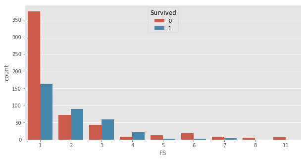

```python
fig, ax = plt.subplots(figsize=(10,5))
sns.countplot(x='FS', hue='Survived',data=train)
plt.show()
```

上面生成title属性是因为，对于不同社会地位的人来说，title也是不同的，所以对于是否能够幸存也是有影响的，所以就可以用数字来代替不同的title；

然后是FamilySize属性，我统计了一下每个人的家庭规模，然后又进行了可视化，根据结果可以看出，只有家庭规模在2、3、4的时候幸存的比例才比死亡的多，而其他更少或更多的时候幸存的都要少，所以我认为独身一人时没有帮手是不容易存活的，在反过来说，当人数过多时，也是不容易存活的，因为整个家庭规模过大会导致不够灵活，处理事情不够迅速，必然会导致死亡，所以家庭规模的大小与是否存活之间也是有关联的

接下来是NameLength属性，之所以生成这个属性也是因为有看到网上说姓名越短则代表身份越尊贵，也就是社会地位越高，那么自然幸存的可能性就变大了

接着是还要对这些属性离散化，因为对于连续性的变量来说，离散化可以防止模型过拟合，让模型变得更稳定

最后在对Sex属性进行独热编码的处理

这里我增加了一个新的属性isAlone，该属性的意思是标注该名乘客是否是孤身一人，通过属性FS来判断，如果FS=1则说明他是一个人，是没有同伴的，用1来标注；但如果FS是其他数字，则表示该乘客是有人陪伴的，则用0来标注，我是想通过这个属性来看看是否是孤身一人与幸存与否之间有什么关系

```python
train['isAlone'] = 0
train.loc[train['FS'] == 1,'isAlone'] = 1
```

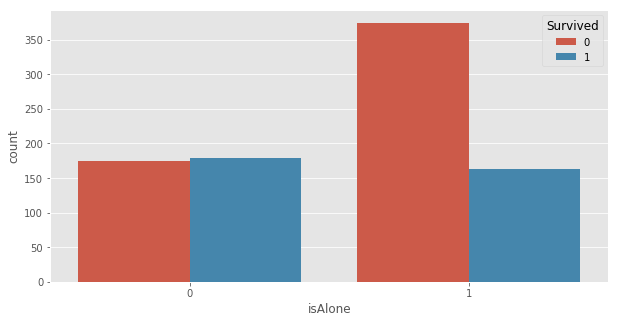

```python
fig, ax = plt.subplots(figsize=(10,5))
sns.countplot(x='isAlone', hue='Survived',data=train)
plt.show()
```

```python
train[['isAlone','Survived']].groupby(['isAlone'],as_index=False).mean().sort_values(by='Survived',ascending=True)
```

|  | isAlone | Survived |
| --- | --- | --- |
| 1 | 1 | 0.303538 |
| 0 | 0 | 0.505650 |

从可视化的结果和表格可以发现，如果是孤身一人的话则存活概率比较小，只有30%；但是如果你不是孤身一人，是有伴儿的话，那么幸存的概率是50%，所以也就可以看出，是否是孤身一人与是否幸存之间是有一定关系的，但是不能作为是否幸存的关键要素

下面我在针对Age和Sex衍生一个新的属性Person，该属性是针对不同年龄和性别进行分段，14岁以下以下是儿童，有优先被救权，然后是大于14岁的女性也有优先权，我标注为female_adult，最后如果是大于14岁，性别为男性的话，就标记为male_adult，而这样的人幸存概率是相对更低的，是没有优先权的

```python
# 生成儿童、成年男性和成年女性的标签
child_age = 14
def get_person(passenger):
    age, sex = passenger
    if (age < child_age):
        return 'child'
    elif (sex == 'female'):
        return 'female_adult'
    else:
        return 'male_adult'
```

定义一个函数，用来针对不同年龄设定不同的标签

```python
train = pd.concat([train, pd.DataFrame(train[['Age', 'Sex']].apply(get_person, axis=1), columns=['Person'])],axis=1)
train = pd.concat([train,pd.get_dummies(train['Person'])],axis=1)
```

应用上面定义的函数并根据数据中的Age和Sex来给设定不同的标签

```python
train[['Person','Survived']].groupby(['Person'],as_index=False).mean().sort_values(by='Survived',ascending=False)
```

|  | Person | Survived |
| --- | --- | --- |
| 1 | female_adult | 0.757143 |
| 0 | child | 0.591549 |
| 2 | male_adult | 0.162963 |

从这个表格可以看出，成年女性的幸存概率非常大，有76%；儿童的幸存概率也不低，有59%；只有成年男性的幸存概率非常低，只有16%

```python
table_ticket = pd.DataFrame(train["Ticket"].value_counts())
table_ticket.rename(columns={'Ticket':'Ticket_Numbers'}, inplace=True)
table_ticket['Ticket_dead_women'] = train.Ticket[(train.female_adult == 1.0)
                                    & (train.Survived == 0.0)
                                    & ((train.Parch > 0) | (train.SibSp > 0))].value_counts()

table_ticket['Ticket_dead_women'] = table_ticket['Ticket_dead_women'].fillna(0)
table_ticket['Ticket_dead_women'][table_ticket['Ticket_dead_women'] > 0] = 1.0

table_ticket['Ticket_surviving_men'] = train.Ticket[(train.male_adult == 1.0)
                                    & (train.Survived == 1.0)
                                    & ((train.Parch > 0) | (train.SibSp > 0))].value_counts()

table_ticket['Ticket_surviving_men'] = table_ticket['Ticket_surviving_men'].fillna(0)
table_ticket['Ticket_surviving_men'][table_ticket['Ticket_surviving_men'] > 0] = 1.0

# Ticket特征量化
table_ticket["Ticket_Id"] = pd.Categorical(table_ticket.index).codes

table_ticket["Ticket_Id"][table_ticket["Ticket_Numbers"] < 3 ] = -1
# Ticket数量分箱
table_ticket["Ticket_Numbers"] = pd.cut(table_ticket["Ticket_Numbers"], bins=[0,1,4,20], labels=[0,1,2])

train = pd.merge(train, table_ticket, left_on="Ticket",right_index=True, how='left', sort=False)
```

这里使用了一些条件对数据进行了筛选并统计了人数，因为如果票号一样，那就证明他们一定是一家人，然后又因为男女之间在是否幸存上也是存在明显差异的，所以根据这些可以生成新的属性

```python
from sklearn.ensemble import RandomForestClassifier, ExtraTreesRegressor

classers = ['Fare','Parch','Pclass','SibSp','NewTitle',
            'female','male', 'Embarked', 'FamilySize', 'NameLength','Ticket_Numbers','Ticket_Id']
etr = ExtraTreesRegressor(n_estimators=200,random_state=0)
X_train = train[classers][train['Age'].notnull()]
Y_train = train['Age'][train['Age'].notnull()]
X_test = train[classers][train['Age'].isnull()]

etr.fit(X_train.as_matrix(),np.ravel(Y_train))
age_preds = etr.predict(X_test.as_matrix())
train['Age'][train['Age'].isnull()] = age_preds
```

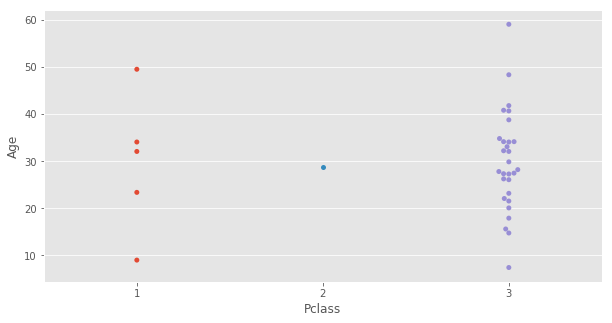

```python
# Age缺失值填补后的情况
X_test['Age'] = pd.Series(age_preds)
f,ax=plt.subplots(figsize=(10,5))
sns.swarmplot(x='Pclass',y='Age',data=X_test)
plt.show()
```

对拟合出来的Age数据进行可视化，数据分布也是比较合理的

```python
train.loc[train['Age'] <= 14,'Age'] = 0
train.loc[(train['Age'] > 14) & (train['Age'] <= 32),'Age'] = 1
train.loc[(train['Age'] > 32) & (train['Age'] <= 48),'Age'] = 2
train.loc[(train['Age'] > 48) & (train['Age'] <= 64),'Age'] = 3
train.loc[train['Age'] > 64,'Age'] = 4
```

```python
#Display data missing values
total = train.isnull().sum().sort_values(ascending=False)
percent = round(train.isnull().sum().sort_values(ascending=False)/len(train)*100,2)
pd.concat([total,percent],axis=1,keys=['total','percent'])
```

|  | total | percent |
| --- | --- | --- |
| Cabin | 687 | 77.1 |
| Ticket_Id | 0 | 0.0 |
| Ticket_surviving_men | 0 | 0.0 |
| Survived | 0 | 0.0 |
| Pclass | 0 | 0.0 |
| Name | 0 | 0.0 |
| Sex | 0 | 0.0 |
| Age | 0 | 0.0 |
| SibSp | 0 | 0.0 |
| Parch | 0 | 0.0 |
| Ticket | 0 | 0.0 |
| Fare | 0 | 0.0 |
| Embarked | 0 | 0.0 |
| FS | 0 | 0.0 |
| Title | 0 | 0.0 |
| NewTitle | 0 | 0.0 |
| FamilySize | 0 | 0.0 |
| NameLength | 0 | 0.0 |
| female | 0 | 0.0 |
| male | 0 | 0.0 |
| isAlone | 0 | 0.0 |
| Person | 0 | 0.0 |
| child | 0 | 0.0 |
| female_adult | 0 | 0.0 |
| male_adult | 0 | 0.0 |
| Ticket_Numbers | 0 | 0.0 |
| Ticket_dead_women | 0 | 0.0 |
| PassengerId | 0 | 0.0 |

下面继续对训练数据中的Cabin属性进行处理。经过之前的统计，Cabin属性有很多的缺失值，占了总数据的77%，直接删除是不合适的，会造成重要数据信息的缺失，该属性是每个乘客的船舱座位号，缺失值太多，但是这个属性很难进行处理，填充任何值都有很大可能引入噪声，所以可以采用不处理的方式，但是要生成一个新的属性来标明缺失与否，这里可以用0代表包含缺失值，而其他的用首字母来标识

```python
train['NewCabin'] = pd.Categorical(train.Cabin.fillna('0').apply(lambda x: x[0])).codes
```

训练数据中已经没有缺失值了，现在可以开始处理测试数据中的缺失值了

训练数据处理完以后，下面对测试数据进行处理

```python
#Display data missing values
total = test.isnull().sum().sort_values(ascending=False)
percent = round(test.isnull().sum().sort_values(ascending=False)/len(test)*100,2)
pd.concat([total,percent],axis=1,keys=['total','percent'])
```

|  | total | percent |
| --- | --- | --- |
| Cabin | 327 | 78.23 |
| Age | 86 | 20.57 |
| Fare | 1 | 0.24 |
| Embarked | 0 | 0.00 |
| Ticket | 0 | 0.00 |
| Parch | 0 | 0.00 |
| SibSp | 0 | 0.00 |
| Sex | 0 | 0.00 |
| Name | 0 | 0.00 |
| Pclass | 0 | 0.00 |
| PassengerId | 0 | 0.00 |
| Survived | 0 | 0.00 |

由表可知，测试数据中的缺失值有Cabin、Age和Fare，我们可以先看看Fare，因为它只有一条，处理起来更方便

```python
test.loc[test.Fare.isnull()]
```

|  | Survived | PassengerId | Pclass | Name | Sex | Age | SibSp | Parch | Ticket | Fare | Cabin | Embarked |
| --- | --- | --- | --- | --- | --- | --- | --- | --- | --- | --- | --- | --- |
| 152 | 0 | 1044 | 3 | Storey, Mr. Thomas | male | 60.5 | 0 | 0 | 3701 | NaN | NaN | S |

填充这个缺失值的方式可以采用，寻找与该数据相似的数据，然后再基于相似数据中Fare的平均值来进行填充

```python
NewFare = test.loc[test['Pclass']==3].Fare.mean()
test.Fare.fillna(NewFare,inplace=True)
```

处理完Fare的缺失值之后，继续处理Age中的缺失值

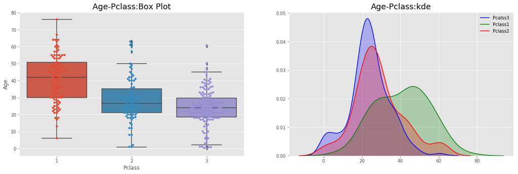

```python
# 箱型图特征分析
fig, [ax1,ax2] = plt.subplots(1,2,figsize=(20,6))
sns.boxplot(x="Pclass", y="Age", data=test, ax =ax1)
sns.swarmplot(x="Pclass", y="Age", data=test, ax =ax1)
sns.kdeplot(test.loc[(test['Pclass'] == 3),'Age'] , color='b',shade=True, label='Pcalss3',ax=ax2)
sns.kdeplot(test.loc[(test['Pclass'] == 1),'Age'] , color='g',shade=True, label='Pclass1',ax=ax2)
sns.kdeplot(test.loc[(test['Pclass'] == 2),'Age'] , color='r',shade=True, label='Pclass2',ax=ax2)
ax1.set_title('Age-Pclass:Box Plot', fontsize = 18)
ax2.set_title("Age-Pclass:kde", fontsize = 18)
fig.show()
```

通过对测试数据进行可视化，可以发现与训练数据中同样的规律，所以填充时也采用同样的方式

之前在训练数据针对Age是有两种方式的，那么测试数据也是一样的

针对Age的处理方式一

```python
scipy.stats.shapiro(test.Age)
```

```
(nan, 1.0)
```

```python
#求对应分布的Age的平均值
Age1 = int(test.loc[test.Pclass == 1,'Age'].mean())
Age2 = int(test.loc[test.Pclass == 1,'Age'].mean())
Age3 = int(test.loc[test.Pclass == 1,'Age'].mean())
```

```python
#拆分数据
test1 = test.loc[test.Pclass == 1]
test2 = test.loc[test.Pclass == 2]
test3 = test.loc[test.Pclass == 3]
```

```python
#填充
test1.Age.fillna(Age1,inplace=True)
test2.Age.fillna(Age2,inplace=True)
test3.Age.fillna(Age3,inplace=True)
```

```python
#合并
test = pd.concat([test1,test2,test3])
```

```python
#打乱排序
test.sort_values("PassengerId",inplace=True)
```

针对Age的处理方式二

```python
test.info()
```

[output not shown]

因为属性中还有很多不是数值类型的，所以还需要对其进行处理，与训练数据中的处理方式是一样的

```python
import re
test["Title"] = test["Name"].apply(lambda x: re.search(' ([A-Za-z]+)\.',x).group(1))
title_mapping = {"Mr": 1, "Miss": 2, "Mrs": 3, "Master": 4, "Dr": 5, "Rev": 6, "Major": 7, "Col": 7, "Mlle": 2, "Mme": 3,"Don": 9,"Dona": 9, "Lady": 10, "Countess": 10, "Jonkheer": 10, "Sir": 9, "Capt": 7, "Ms": 2}

# 量化Title信息
test["NewTitle"] = test.loc[:,'Title'].map(title_mapping)

# SibSp和Parch属性进行组合
test["FamilySize"] = test["SibSp"] + test["Parch"] + 1

# 根据FamilySize分布进行分箱
test["FamilySize"] = pd.cut(test["FamilySize"], bins=[0,1,4,20], labels=[0,1,2])

# 从Name衍生出Name的长度
test["NameLength"] = test["Name"].apply(lambda x: len(x))

#量化Embarked
test["Embarked"] = pd.Categorical(test.Embarked).codes

# 对Sex进行独热编码分组
test = pd.concat([test,pd.get_dummies(test['Sex'])],axis=1)
```

上面使用了与训练数据中同样的处理方式

```python
#计算家庭规模人数
test['FS'] = test['SibSp'] + test['Parch'] + 1

#定义新的属性isAlone
test['isAlone'] = 0
test.loc[test['FS'] == 1,'isAlone'] = 1
```

```python
# 生成儿童、成年男性和成年女性的标签
child_age = 14
def get_person(passenger):
    age, sex = passenger
    if (age < child_age):
        return 'child'
    elif (sex == 'female'):
        return 'female_adult'
    else:
        return 'male_adult'
```

定义一个函数，用来针对测试数据中不同年龄设定不同的标签

```python
test = pd.concat([test, pd.DataFrame(test[['Age', 'Sex']].apply(get_person, axis=1), columns=['Person'])],axis=1)
test = pd.concat([test,pd.get_dummies(test['Person'])],axis=1)
```

应用上面定义的函数并根据数据中的Age和Sex来给设定不同的标签

```python
table_ticket = pd.DataFrame(test["Ticket"].value_counts())
table_ticket.rename(columns={'Ticket':'Ticket_Numbers'}, inplace=True)
table_ticket['Ticket_dead_women'] = test.Ticket[(test.female_adult == 1.0)
                                    & (test.Survived == 0.0)
                                    & ((test.Parch > 0) | (test.SibSp > 0))].value_counts()

table_ticket['Ticket_dead_women'] = table_ticket['Ticket_dead_women'].fillna(0)
table_ticket['Ticket_dead_women'][table_ticket['Ticket_dead_women'] > 0] = 1.0

table_ticket['Ticket_surviving_men'] = test.Ticket[(test.male_adult == 1.0)
                                    & (test.Survived == 1.0)
                                    & ((test.Parch > 0) | (test.SibSp > 0))].value_counts()

table_ticket['Ticket_surviving_men'] = table_ticket['Ticket_surviving_men'].fillna(0)
table_ticket['Ticket_surviving_men'][table_ticket['Ticket_surviving_men'] > 0] = 1.0

# Ticket特征量化
table_ticket["Ticket_Id"] = pd.Categorical(table_ticket.index).codes

table_ticket["Ticket_Id"][table_ticket["Ticket_Numbers"] < 3 ] = -1
# Ticket数量分箱
table_ticket["Ticket_Numbers"] = pd.cut(table_ticket["Ticket_Numbers"], bins=[0,1,4,20], labels=[0,1,2])

test = pd.merge(test, table_ticket, left_on="Ticket",right_index=True, how='left', sort=False)
```

与训练数据中处理的方式一样

```python
test.info()
```

```
<class 'pandas.core.frame.DataFrame'>
RangeIndex: 418 entries, 0 to 417
Data columns (total 28 columns):
Survived                418 non-null int64
PassengerId             418 non-null int64
Pclass                  418 non-null int64
Name                    418 non-null object
Sex                     418 non-null object
Age                     332 non-null float64
SibSp                   418 non-null int64
Parch                   418 non-null int64
Ticket                  418 non-null object
Fare                    418 non-null float64
Cabin                   91 non-null object
Embarked                418 non-null int8
Title                   418 non-null object
NewTitle                418 non-null int64
FamilySize              418 non-null category
NameLength              418 non-null int64
female                  418 non-null uint8
male                    418 non-null uint8
FS                      418 non-null int64
isAlone                 418 non-null int64
Person                  418 non-null object
child                   418 non-null uint8
female_adult            418 non-null uint8
male_adult              418 non-null uint8
Ticket_Numbers          418 non-null category
Ticket_dead_women       418 non-null float64
Ticket_surviving_men    418 non-null float64
Ticket_Id               418 non-null int16
dtypes: category(2), float64(4), int16(1), int64(9), int8(1), object(6), uint8(5)
memory usage: 66.4+ KB
```

```python
from sklearn.ensemble import RandomForestClassifier, ExtraTreesRegressor
classers = ['Fare','Parch','Pclass','SibSp','NewTitle',
            'female','male', 'Embarked', 'FamilySize', 'NameLength','Ticket_Numbers','Ticket_Id']

etr = ExtraTreesRegressor(n_estimators=200,random_state=0)
X_train = test[classers][test['Age'].notnull()]
Y_train = test['Age'][test['Age'].notnull()]
X_test = test[classers][test['Age'].isnull()]

etr.fit(X_train.as_matrix(),np.ravel(Y_train))
age_preds = etr.predict(X_test.as_matrix())
test['Age'][test['Age'].isnull()] = age_preds
```

```python
test.info()
```

```
<class 'pandas.core.frame.DataFrame'>
RangeIndex: 418 entries, 0 to 417
Data columns (total 28 columns):
Survived                418 non-null int64
PassengerId             418 non-null int64
Pclass                  418 non-null int64
Name                    418 non-null object
Sex                     418 non-null object
Age                     418 non-null float64
SibSp                   418 non-null int64
Parch                   418 non-null int64
Ticket                  418 non-null object
Fare                    418 non-null float64
Cabin                   91 non-null object
Embarked                418 non-null int8
Title                   418 non-null object
NewTitle                418 non-null int64
FamilySize              418 non-null category
NameLength              418 non-null int64
female                  418 non-null uint8
male                    418 non-null uint8
FS                      418 non-null int64
isAlone                 418 non-null int64
Person                  418 non-null object
child                   418 non-null uint8
female_adult            418 non-null uint8
male_adult              418 non-null uint8
Ticket_Numbers          418 non-null category
Ticket_dead_women       418 non-null float64
Ticket_surviving_men    418 non-null float64
Ticket_Id               418 non-null int16
dtypes: category(2), float64(4), int16(1), int64(9), int8(1), object(6), uint8(5)
memory usage: 66.4+ KB
```

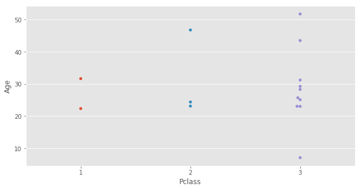

```python
# Age缺失值填补后的情况
X_test['Age'] = pd.Series(age_preds)
f,ax=plt.subplots(figsize=(10,5))
sns.swarmplot(x='Pclass',y='Age',data=X_test)
plt.show()
```

查看预测结果的分布情况

```python
test.loc[test['Age'] <= 16,'Age'] = 0
test.loc[(test['Age'] > 16) & (test['Age'] <= 32),'Age'] = 1
test.loc[(test['Age'] > 32) & (test['Age'] <= 48),'Age'] = 2
test.loc[(test['Age'] > 48) & (test['Age'] <= 64),'Age'] = 3
test.loc[test['Age'] > 64,'Age'] = 4
```

处理完Age之后就剩Cabin了

```python
test['NewCabin'] = pd.Categorical(test.Cabin.fillna('0').apply(lambda x: x[0])).codes
```

这里为了处理Cabin中的缺失值采用了与训练数据中处理Cabin缺失值同样的方式

```python
#Display data missing values
total = test.isnull().sum().sort_values(ascending=False)
percent = round(test.isnull().sum().sort_values(ascending=False)/len(test)*100,2)
pd.concat([total,percent],axis=1,keys=['total','percent'])
```

|  | total | percent |
| --- | --- | --- |
| Cabin | 327 | 78.23 |
| NewCabin | 0 | 0.00 |
| NewTitle | 0 | 0.00 |
| PassengerId | 0 | 0.00 |
| Pclass | 0 | 0.00 |
| Name | 0 | 0.00 |
| Sex | 0 | 0.00 |
| Age | 0 | 0.00 |
| SibSp | 0 | 0.00 |
| Parch | 0 | 0.00 |
| Ticket | 0 | 0.00 |
| Fare | 0 | 0.00 |
| Embarked | 0 | 0.00 |
| Title | 0 | 0.00 |
| FamilySize | 0 | 0.00 |
| Ticket_Id | 0 | 0.00 |
| NameLength | 0 | 0.00 |
| female | 0 | 0.00 |
| male | 0 | 0.00 |
| FS | 0 | 0.00 |
| isAlone | 0 | 0.00 |
| Person | 0 | 0.00 |
| child | 0 | 0.00 |
| female_adult | 0 | 0.00 |
| male_adult | 0 | 0.00 |
| Ticket_Numbers | 0 | 0.00 |
| Ticket_dead_women | 0 | 0.00 |
| Ticket_surviving_men | 0 | 0.00 |
| Survived | 0 | 0.00 |

现在训练数据和测试数据中的所有的缺失值都进行了处理，接下来需要筛选一下属性，因为并不是一定要用到所有的属性来训练模型，有些属性对模型的训练没有帮助或帮助不大，所以需要进行筛选,这也算是属性规约，简化属性维度，降低计算成本

```python
from sklearn.feature_selection import SelectKBest, f_classif,chi2

target = train["Survived"].values
features= ['female','male','Age','male_adult','female_adult', 'child','NewTitle',
           'Pclass','Ticket_Id','NameLength','NewCabin', 'SibSp', 'Parch',
           'Fare','Embarked','Ticket_Numbers','FamilySize',
           'Ticket_dead_women','Ticket_surviving_men','isAlone'
          ]

X_train = train.copy()
X_test = test.copy()

selector = SelectKBest(f_classif, k=len(features))
selector.fit(train[features], target)
scores = -np.log10(selector.pvalues_)
indices = np.argsort(scores)[::-1]
print("Features importance :")
for f in range(len(scores)):
    print("%0.2f %s" % (scores[indices[f]],features[indices[f]]))
```

```
Features importance :
75.02 male_adult
68.85 female
68.85 male
62.05 female_adult
26.22 NewTitle
24.60 Pclass
23.69 NameLength
17.75 NewCabin
17.41 Ticket_surviving_men
14.21 Fare
13.54 Ticket_dead_women
9.05 isAlone
6.78 Embarked
3.90 Ticket_Numbers
3.77 child
2.93 FamilySize
1.83 Parch
1.64 Age
0.53 SibSp
0.09 Ticket_Id
```

这其实就是对所选定的属性进行打分，分数越高的则代表对结果的预测就越有帮助，相反的则对结果没有帮助或很小的帮助

对所选定的属性打完分后，就可以知道哪些属性对结果的预测是更有帮助的，但是属性与属性之间还存在一个情况就是相关性的问题，如果学习了很多相关性很强的属性，那么哪怕是打分很高的属性，最终训练的模型也不会很好，会造成模型的过拟合问题。就好像是学习了很多相似的东西，那么学习的结果就不会很全面，模型就不会很好了，所以下面生成了关于属性之间的热图

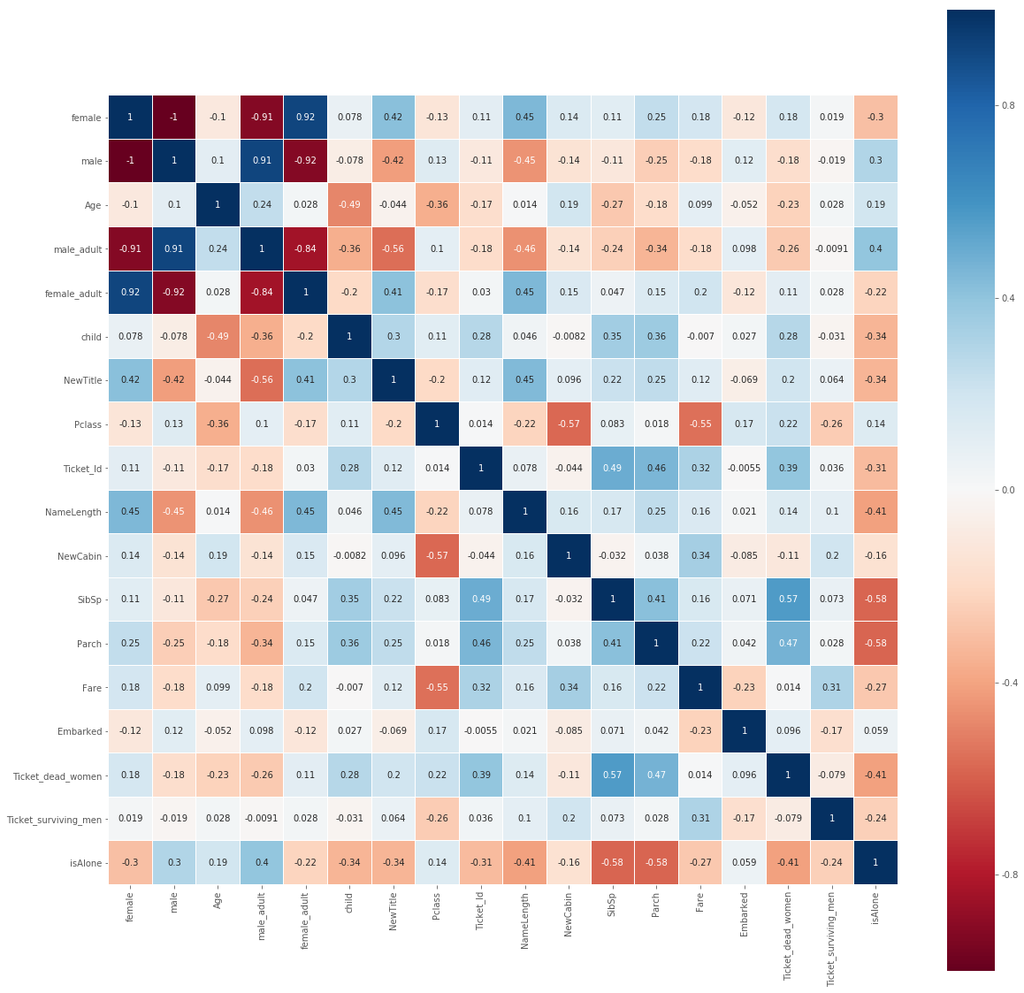

```python
features_selected = features
# data_corr
train_corr = train[features_selected].copy()

colormap = plt.cm.RdBu
plt.figure(figsize=(20,20))
sns.heatmap(train_corr.corr(),linewidths=0.1,vmax=1.0, square=True, cmap=colormap, linecolor='white', annot=True)
plt.show()
```

从图中可以看出，颜色越深的属性之间的相关性是越大的，而最终选择属性的依据是相关性低且打分很高的属性就是最优的属性了

```python
from sklearn import cross_validation

rfc = RandomForestClassifier(n_estimators=3000, min_samples_split=4, class_weight={0:0.745,1:0.255})
# rfc = AdaBoostClassifier(n_estimators=3000, learning_rate=0.1, random_state=1)

# 交叉验证，建模随机森林
kf = cross_validation.KFold(train.shape[0], n_folds=3, random_state=1)

scores = cross_validation.cross_val_score(rfc, train[features_selected], target, cv=kf)
print("Accuracy: %0.3f (+/- %0.2f) [%s]" % (scores.mean()*100, scores.std()*100, 'RFC Cross Validation'))
rfc.fit(train[features_selected], target)
score = rfc.score(train[features_selected], target)
print("Accuracy: %0.3f            [%s]" % (score*100, 'RFC full test'))
importances = rfc.feature_importances_
indices = np.argsort(importances)[::-1]
for f in range(len(features_selected)):
    print("%d. feature %d (%f) %s" % (f + 1, indices[f]+1, importances[indices[f]]*100, features_selected[indices[f]]))
```

```
Accuracy: 89.562 (+/- 0.48) [RFC Cross Validation]
Accuracy: 95.511            [RFC full test]
1. feature 18 (12.627284) Ticket_dead_women
2. feature 14 (12.547923) Fare
3. feature 10 (12.090043) NameLength
4. feature 4 (7.380880) male_adult
5. feature 8 (6.852084) Pclass
6. feature 19 (6.268955) Ticket_surviving_men
7. feature 2 (6.116051) male
8. feature 7 (5.998274) NewTitle
9. feature 1 (5.265501) female
10. feature 5 (4.274123) female_adult
11. feature 11 (3.764284) NewCabin
12. feature 17 (3.112066) FamilySize
13. feature 3 (2.777870) Age
14. feature 16 (2.164395) Ticket_Numbers
15. feature 15 (2.128420) Embarked
16. feature 9 (1.817405) Ticket_Id
17. feature 12 (1.774759) SibSp
18. feature 20 (1.318785) isAlone
19. feature 13 (0.975723) Parch
20. feature 6 (0.745175) child
```

这里我使用的是K折交叉的方式进行采样，使用了模型自带的打分机制对其进行可视化，展示结果

这里使用的模型是随机森林，随机森林的性能主要由每棵树的性能和树之间的相关性和树的个数来决定的，每棵树的性能会随着所使用的属性越多而提高，但是随着属性的增多，会导致树之间的相关性增强，这是不好的现象，因为随机森林是集成所有树给出的结果来进行决策的，但如果树之间的相关性很高，那么不同树给出的结果就越相似，参考性就降低了，所以随机森林是希望可以集成多个不同的树的结果来做决策，相关性越高，只会让树之间越相似。所以在树的个数和树所使用的属性之间是需要权衡，需要调参的，不同的参数会带来不一样的结果，所以不断调参也是一个漫长的过程，需要找到最优的参数组合，才能得到性能好的机器学习模型

```python
# 预测目标值
rfc.fit(train[features_selected],target)
predictions = rfc.predict(test[features_selected])
```

```python
# 输出文件
PassengerId =np.array(test["PassengerId"]).astype(int)
my_prediction = pd.DataFrame(predictions, PassengerId, columns = ["Survived"])

my_prediction.to_csv("my_prediction.csv", index_label = ["PassengerId"])
```

现在就得到了一个结果了